# clus_file

```python
import numpy as np
import astropy.io.fits as fits
import json
import os
import glob
import sys
import healpy as hp
from astropy.table import Table
from astropy import units as u
from astropy.coordinates import SkyCoord, match_coordinates_sky
from astropy.io.fits import getdata
from pathlib import Path
from itertools import compress
import matplotlib.pyplot as plt
from scipy.ndimage import gaussian_filter
import tabulate
```

```python
def read_ref(param):
    Mv, rhl_pc = np.loadtxt(param["cat_dg"], usecols=(8, 10), unpack=True)

    mM_GC, Mv_GC, rhl_arcmin_GC = np.loadtxt(
        param["cat_gc"], usecols=(5, 6, 7), unpack=True
    )

    dist_GC = 10.0 ** (1 + (mM_GC / 5))

    rhl_pc_GC = (rhl_arcmin_GC / (57.3 * 60)) * dist_GC

    rhl_pc = np.concatenate((rhl_pc, rhl_pc_GC))

    Mv = np.concatenate((Mv, Mv_GC))

    return Mv, rhl_pc
```

```python
def read_ref_dg(param):
    Mv, rhl_pc = np.loadtxt(param["cat_dg"], usecols=(8, 10), unpack=True)

    return Mv, rhl_pc
```

```python
def read_ref_gc(param):

    mM_GC, Mv_GC, rhl_arcmin_GC = np.loadtxt(
        param["cat_gc"], usecols=(5, 6, 7), unpack=True
    )

    dist_GC = 10.0 ** (1 + (mM_GC / 5))

    rhl_pc_GC = (rhl_arcmin_GC / (57.3 * 60)) * dist_GC

    return Mv_GC, rhl_pc_GC
```

```python
def rd2d(x, y, xmin, xmax, ymin, ymax, x_steps, y_steps, n_random):
    """This function returns a 2D random of point based on an informed distribution.

    Parameters
    ----------
    x : list of float
        List of points. First dimension.
    y : list of float
        List of points. Second dimension.
    xmin : float
        Minimum in first dimension.
    xmax : float
        Maximum in first dimension.
    ymin : float
        Minimum in second dimension.
    ymax : float
        Maximum in second dimension.
    x_steps : int
        Amount of steps in first dimension.
    y_steps : int
        Amount of steps in second dimension.
    n_random : int
        Amount of points in output.

    Returns
    -------
    Array-like
        First and second dimension of random points.
    """
    h, xedges, ydeges, img = plt.hist2d(
        x, y, bins=[x_steps, y_steps], range=[[xmin, xmax], [ymin, ymax]], density=True
    )
    plt.clf()
    H = gaussian_filter(h.T, sigma=50)
    H /= np.sum(H)
    p = H.flatten()
    n = np.random.choice(np.arange(len(p)), size=n_random, replace=True, p=p)
    x_random = n % x_steps
    y_random = n / y_steps
    x_random = x_random * (xmax - xmin)
    y_random = y_random * (ymax - ymin)
    x_random = x_random / x_steps
    y_random = y_random / y_steps
    x_random += xmin
    y_random += ymin
    return x_random, y_random
```

```python
def mv_hlr_from_data(N_desired, param, prop_from_data, Mv_min=-14.0, Mv_max=2):

    globals().update(param)

    rhl_pc_min = 10.**(1.7 * log10_rexp_min)
    rhl_pc_max = 10.**(1.7 * log10_rexp_max)

    if prop_from_data == 'True':
        Mv, rhl_pc = read_ref(param)
    elif prop_from_data == 'dg':
        Mv, rhl_pc = read_ref_dg(param)
    elif prop_from_data == 'gc':
        Mv, rhl_pc = read_ref_gc(param)

    log10_rhl_pc = np.log10(rhl_pc)

    X, Y = rd2d(Mv, log10_rhl_pc, Mv_min, Mv_max, np.log10(rhl_pc_min), np.log10(rhl_pc_max), 1000, 1000, N_desired)

    return X, Y
```

```python
def select_ipix_clus(nside, ra_min, ra_max, dec_min, dec_max, inclusive=False):
    """Select ipix from a region of sky following same ra and dec ranges
    (insted of Healpix standard geodesics).

    Parameters
    ----------
    nside : integer
        Nside of HealPixels.
    ra_min : float
        Minimum in RA (deg).
    ra_max : float
        Maximum in RA (deg).
    dec_min : float
        Minimum in DEC (deg).
    dec_max : float
        Maximum in DEC (deg).
    inclusive : bool, optional
        If True, all the pixels that are in that region will be selected.
        If False, only the pixels with the center in that region will be
        selected, by default False.

    Returns
    -------
    list
        Sample of requested pixels.
    """
    theta1 = np.pi / 2 - np.deg2rad(dec_max)
    theta2 = np.pi / 2 - np.deg2rad(dec_min)
    hp_all = hp.query_strip(
        nside, theta1, theta2, inclusive=inclusive, nest=False, buff=None
    )
    ra_c, dec_c = hp.pix2ang(nside, hp_all, nest=False, lonlat=True)
    cond = (ra_c > ra_min) & (ra_c <= ra_max)
    hp_sel = hp_all[cond]
    hp_sel_nest = hp.ring2nest(nside, hp_sel)
    return hp_sel_nest
```

```python
def download_iso(version, phot_system, Z, age, av_ext, IMF_author, out_file, iter_max):
    """Submit a request of an isochrone from PADOVA schema, download the file
    requested and uses as an input file to the stellar population of clusters.
    Good reference to Fe/H and M/H and Z:
    https://www.aanda.org/articles/aa/full_html/2014/03/aa20956-12/aa20956-12.html

    Parameters
    ----------
    version : str
        Version of PADOVA/PARSEC isochrones ('3.4', '3.5' or '3.6')
    phot_system : str
        Photometric system of isochrones. For DES uses 'decam'.
    Z : float
        Amount of metals in mass. Z_sun = 0.019.
    age : float
        Age of isochrone in years (not log age).
    av_ext : float
        Extinction in V band. Usually 0.000.
    out_file : str
        Name of the output file, which is written as
        output.
    """

    # os.system('mkdir -p ' + out_file.split('/')[0])
    count = 0
    file_is_empty = True
    # Selecting IMF:
    if IMF_author == "Kroupa":
        file_IMF = "imf_kroupa_orig.dat"
    if IMF_author == "Salpeter":
        file_IMF = "imf_salpeter.dat"
    if IMF_author == "Chabrier_exp":
        file_IMF = "imf_chabrier_exponential.dat"

    main_pars = (
        "track_parsec=parsec_CAF09_v1.2S&track_colibri=parsec_CAF09_v1.2S_S_LMC_08_web&track_postagb="
        +"no&n_inTPC=10&eta_reimers=0.2&kind_interp=1&kind_postagb=-1&kind_tpagb=-1&kind_pulsecycle="
        +"0&kind_postagb=-1&kind_mag=2&kind_dust=0&extinction_coeff=constant&extinction_curve="
        +"cardelli&kind_LPV=1&dust_sourceM=dpmod60alox40&dust_sourceC=AMCSIC15&imf_file=tab_imf/"
        +file_IMF
        +"&output_kind=0&output_evstage=1&output_gzip=0"
    )
    webserver = "http://stev.oapd.inaf.it"
    if phot_system == "des":
        phot_system = "decam"

    while (file_is_empty) & (count < iter_max):
        print("Iteration {:d} to download PARSEC isochrone.".format(count + 1))
        try:
            os.system(
                (
                    "wget -o lixo -Otmp --post-data='submit_form=Submit&cmd_version={}&photsys_file=tab_mag_odfnew/tab_mag_{}.dat&photsys_version=YBC&output_kind=0&output_evstage=1&isoc_isagelog=0&isoc_agelow={:.2e}&isoc_ageupp={:.2e}&isod_dage=0&isoc_ismetlog=0&isoc_zlow={:.6f}&isoc_zupp={:.6f}&isod_dz=0&extinction_av={:.3f}&{}' {}/cgi-bin/cmd_{}".format(
                        version,
                        phot_system,
                        age,
                        age,
                        Z,
                        Z,
                        av_ext,
                        main_pars,
                        webserver,
                        version,
                    )
                ).replace("e+", "e")
            )
        except:
            print("No communication with {}".format(webserver))
        with open("tmp") as ff:
            aaa = ff.readlines()
            for i, j in enumerate(aaa):
                if "/output" in j:
                    out_file_tmp = (
                        "output"
                        +j.split(
                            "/output",
                        )[
                            1
                        ][0:12]
                        +".dat"
                    )
        os.system(
            "wget -o lixo -O{} {}/tmp/{}".format(out_file_tmp, webserver, out_file_tmp)
        )
        os.system("mv {} {}".format(out_file_tmp, out_file))

        file_is_empty = os.stat(out_file).st_size == 0

        count += 1
```

```python
def gen_clus_file(param):
    """This function generates the file with features of simulated clusters,
    based on numerical simulations within the range of parameters.

    Parameters
    ----------
    param : dictionary
        Dictionary with all the list of parameters.

    Returns
    -------
    list
        RA_pix, DEC_pix, r_exp, ell, pa, dist, mass, mM, hp_sample_un
        Position of the center of ipix, exponential radius in parsecs,
        ellipticity. positional angle, distance in parsecs, mass in
        Sun masses, distance modulus, and list of ipix sampled.
    """

    globals().update(param)

    border_extract_ra = border_extract / np.cos(np.deg2rad(0.5 * (dec_max + dec_min)))
    hp_sample_un = select_ipix_clus(
        nside_ini,
        ra_min + border_extract_ra,
        ra_max - border_extract_ra,
        dec_min + border_extract,
        dec_max - border_extract,
    )

    RA_pix, DEC_pix = hp.pix2ang(nside_ini, hp_sample_un, nest=True, lonlat=True)

    c = SkyCoord(ra=RA_pix * u.degree, dec=DEC_pix * u.degree, frame="icrs")
    L = c.galactic.l.degree
    B = c.galactic.b.degree
    objects_filepath = Path(results_path, "objects.dat")
    with open(objects_filepath, "w") as obj_file:
        # Creating random distances, masses, ellipticities and positional
        # angles based on limits required, and printing to file objects.dat.
        mM = mM_min + np.random.rand(len(hp_sample_un)) * (mM_max - mM_min)
        dist = 10 ** ((mM / 5) + 1)

        if Mv_hlr_from_data != 'False':
            MV, hlr_prev = mv_hlr_from_data(len(hp_sample_un), param, Mv_hlr_from_data, Mv_min, Mv_max)
            r_exp = [(10 ** i) / 1.7 for i in hlr_prev]
        else:
            r_exp = 10**(log10_rexp_min + (log10_rexp_max - log10_rexp_min)
                        ** np.random.rand(len(hp_sample_un)))
            MV = Mv_min + (Mv_max - Mv_min) * np.random.rand(len(hp_sample_un))

        ell = ell_min + np.random.rand(len(hp_sample_un)) * (ell_max - ell_min)
        pa = pa_min + np.random.rand(len(hp_sample_un)) * (pa_max - pa_min)

        print("# HPX L       B        RA     DEC     r_exp ell  pa     MV    dist", file=obj_file)

        for i in range(len(hp_sample_un)):
            print(
                "{:d} {:.4f} {:.4f} {:.4f} {:.4f} {:.2f} {:.2f} {:.2f} {:.2f} {:.2f}".format(
                    hp_sample_un[i],
                    L[i],
                    B[i],
                    RA_pix[i],
                    DEC_pix[i],
                    r_exp[i],
                    ell[i],
                    pa[i],
                    MV[i],
                    dist[i],
                ),
                file=obj_file,
            )
    return RA_pix, DEC_pix, r_exp, ell, pa, dist, mM, hp_sample_un, MV
```

```python
def show_plots(Mv_DG, Mv_GC, MV, hlr_DG, hlr_GC, hlr_pc):
    f, ((ax1, ax2), (ax3, ax4)) = plt.subplots(2, 2, figsize=(15, 10))
    ax1.scatter(hlr_pc, MV, color='r', s=5.0, label='Simulation')
    ax1.scatter(hlr_DG, Mv_DG, color='b', s=25, lw=0.5, label='Dwarf galaxies', marker='x')
    ax1.scatter(hlr_GC, Mv_GC, color='k', s=25, lw=0.5, label='Globular Clusters', marker='x')
    ax1.set_xlabel(r'$r_{1/2}$')
    ax1.set_ylabel(r'$M_V$')
    ax1.set_ylim([3, -14])
    ax1.set_xlim([0.5, 4000])
    ax1.legend()
    ax1.set_xscale('log')

    weights = np.ones_like(hlr_DG) / len(hlr_DG)

    ax2.hist(np.log10(hlr_DG), bins=20, histtype="step",
             range=(.316, 2.6), label="DG", color="g", alpha=0.5,
             weights=weights, lw=2)

    weights = np.ones_like(hlr_GC) / len(hlr_GC)

    ax2.hist(np.log10(hlr_GC), bins=20, histtype="step",
             range=(.316, 2.6), label="GC", color="b",
             weights=weights, lw=2)
    weights = np.ones_like(hlr_pc) / len(hlr_pc)

    ax2.hist(np.log10(hlr_pc), bins=20, histtype="stepfilled", range=(
             .316, 2.6), label="Sim filt", color="red", ls="--", alpha=0.5,
             weights=weights, lw=2)
    ax2.set_ylabel("Fraction")
    ax2.set_xlabel(r"$log_{10}r_{1/2}$[pc]")
    # ax2.set_xscale('log')
    ax2.set_xlim([0.316, 2.6])
    ax2.legend(loc=1)
    ax2.set_title(r'Histogram of $log_{10} r_{1/2}$ (parsecs)')

    ax3.hist(Mv_DG, bins=20, range=(-16, 2.0),
             histtype="step", label="DG", color="g", alpha=0.5,
             density=True, #weights=np.repeat(0.9*len(MAG_ABS_V_CLEAN)/len(Mv_DG), len(Mv_DG)),
             lw=2)
    ax3.hist(Mv_GC, bins=20, range=(-16, 2.0),
             histtype="step", label="GC", color="b",
             density=True, #weights=np.repeat(0.9*len(MAG_ABS_V_CLEAN)/len(Mv_GC), len(Mv_GC)),
             lw=2)
    ax3.hist(MV, bins=20, range=(-16, 2.0), histtype="stepfilled",
             label="Sim", color="r", ls="--", alpha=0.5, lw=2,
             density=True)
    ax3.set_xlabel(r"$M_V$")
    ax3.set_ylabel("Fraction")
    ax3.legend(loc=2)
    ax3.set_title('Histogram of Absolute Magnitude (V band)')
    weights = np.ones_like(hlr_DG) / len(hlr_DG)

    ax4.hist(hlr_DG, bins=20, histtype="step",
             range=(1, 400), label="DG", color="g", alpha=0.5,
             weights=weights, lw=2)

    weights = np.ones_like(hlr_GC) / len(hlr_GC)

    ax4.hist(hlr_GC, bins=20, histtype="step",
             range=(1, 400), label="GC", color="b",
             weights=weights, lw=2)
    weights = np.ones_like(hlr_pc) / len(hlr_pc)

    ax4.hist(hlr_pc, bins=20, histtype="stepfilled", range=(
             1, 400), label="Sim filt", color="red", ls="--", alpha=0.5,
             weights=weights, lw=2)
    ax4.set_ylabel("Fraction")
    ax4.set_xlabel(r"$r_{1/2}$[pc]")
    # ax4.set_xscale('log')
    # ax4.set_xlim([0.001, 400])
    ax4.legend(loc=1)
    ax4.set_title(r'Histogram of $r_{1/2}$ (parsecs)')
    plt.show()
```

## Starting here

Above are just functions created for this jupyter notebook adapted from the functions of simulations. The core of the functions remain the same, but a few inputs have been changed to run here.

First of all, set the parameters of ga_sim.json file. Mv_hlr_from_data parameter may be "True" (simulations according MV and r1/2 distribution), "False" (flat likelihood in Mv r1/2 space), "gc" (simulations similar to globular clusters) or "dg" (simulation similar to dwarf galaxies).

```python
confg = "ga_sim.json"

with open(confg) as fstream:
    param = json.load(fstream)
```

This step is to download an isochrone from PARSEC models. Be sure that your jupyter notebook is connected to web to run this cell properly.

```python
download_iso(param['padova_version_code'], param['survey'], 0.0152 * (10 ** param['MH_simulation']),
             param['age_simulation'], param['av_simulation'], param["IMF_author"], param['file_iso'], 5)
```

```
Iteration 1 to download PARSEC isochrone.
Iteration 2 to download PARSEC isochrone.
```

Now oppening the isochrone file and reading the correect index of column of magnitudes (the index has changed in the last version and to avoid reading wrong cell I implemented this cell).

```python
f = open(param['file_iso'], "r")
cols = f.readlines()
cols = cols[11].split()
cols.pop(0)
n_col_magg = cols.index('gmag')
n_col_magr = cols.index('rmag')
f.close()
```

# GC + DG

Simulating dwarf galaxies and globular clusters. Cell below runs the code and show the plots.

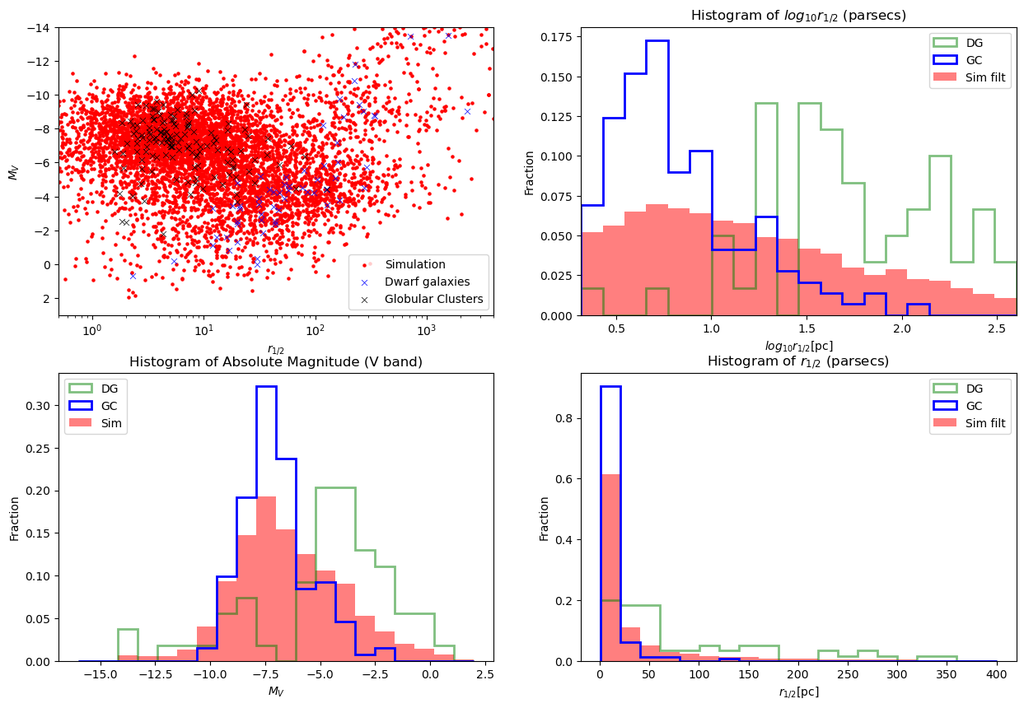

```python
RA_pix, DEC_pix, r_exp, ell, pa, dist, mM, hp_sample_un, MV = gen_clus_file(param)

Mv_DG, hlr_DG = read_ref_dg(param)
Mv_GC, hlr_GC = read_ref_gc(param)

hlr_pc = np.multiply(1.7, r_exp)

show_plots(Mv_DG, Mv_GC, MV, hlr_DG, hlr_GC, hlr_pc)
```

Printing the first 20 lines of the file with the cluster's properties. See the full file for the entire sample.

```python
with open('objects.dat') as f:
    first_line = f.readline()

table = tabulate.tabulate(np.loadtxt('objects.dat')[:][0:20],
                          tablefmt='html',
                          headers=(first_line[1:].split()))

table
```

| HPX | L | B | RA | DEC | r_exp | ell | pa | MV | dist |
| --- | --- | --- | --- | --- | --- | --- | --- | --- | --- |
| 18082 | 99.4542 | -62.0894 | 2.1094 | -1.1937 | 17.8 | 0.16 | 159.22 | -6.06 | 87594.6 |
| 18081 | 102.307 | -62.5593 | 3.5156 | -1.1937 | 3.58 | 0.02 | 43.6 | -7.88 | 14092.5 |
| 18062 | 105.246 | -62.9701 | 4.9219 | -1.1937 | 16.51 | 0.18 | 167.77 | -7.25 | 83401.6 |
| 18061 | 108.261 | -63.3189 | 6.3281 | -1.1937 | 1.88 | 0.17 | 123.94 | -9.41 | 32962.6 |
| 18066 | 111.343 | -63.6033 | 7.7344 | -1.1937 | 47.08 | 0.05 | 8.38 | -8.09 | 63009.3 |
| 18065 | 114.48 | -63.8211 | 9.1406 | -1.1937 | 7.94 | 0.05 | 71.58 | -3.7 | 52190.4 |
| 17982 | 117.657 | -63.9707 | 10.5469 | -1.1937 | 1.26 | 0.05 | 134.89 | -8.31 | 10295.7 |
| 17981 | 120.861 | -64.0509 | 11.9531 | -1.1937 | 0.47 | 0.17 | 172.7 | -7.3 | 23345.9 |
| 18018 | 124.075 | -64.0611 | 13.3594 | -1.1937 | 7.08 | 0.08 | 33.31 | -7.66 | 49974.7 |
| 18017 | 127.283 | -64.0011 | 14.7656 | -1.1937 | 22.19 | 0.12 | 146.33 | -6.23 | 12378 |
| 17998 | 130.469 | -63.8714 | 16.1719 | -1.1937 | 64.54 | 0.14 | 110.74 | -5.68 | 33314.9 |
| 17997 | 133.619 | -63.6732 | 17.5781 | -1.1937 | 1.59 | 0.07 | 27.08 | -9.33 | 83854.3 |
| 18002 | 136.718 | -63.4078 | 18.9844 | -1.1937 | 3.73 | 0.17 | 124.86 | -6.1 | 29801.5 |
| 18001 | 139.754 | -63.0774 | 20.3906 | -1.1937 | 153.08 | 0.17 | 77.76 | -6.64 | 19964.8 |
| 17662 | 142.716 | -62.6843 | 21.7969 | -1.1937 | 1.4 | 0.17 | 163.06 | -6.71 | 58210.3 |
| 17661 | 145.594 | -62.2311 | 23.2031 | -1.1937 | 50.96 | 0.04 | 114.25 | -3.06 | 67923.7 |
| 17826 | 148.383 | -61.7208 | 24.6094 | -1.1937 | 56.64 | 0.08 | 148.03 | -7.32 | 53137.5 |
| 17825 | 151.077 | -61.1565 | 26.0156 | -1.1937 | 1.23 | 0.09 | 13.5 | -6.61 | 49481.4 |
| 17806 | 153.672 | -60.5412 | 27.4219 | -1.1937 | 0.61 | 0.19 | 144.16 | -10.85 | 53458.9 |
| 17805 | 156.168 | -59.8781 | 28.8281 | -1.1937 | 201.21 | 0.08 | 163.26 | -8.9 | 38800 |

# Dwarf galaxies

Changing the parameter to simulate only dwaf galaxies:

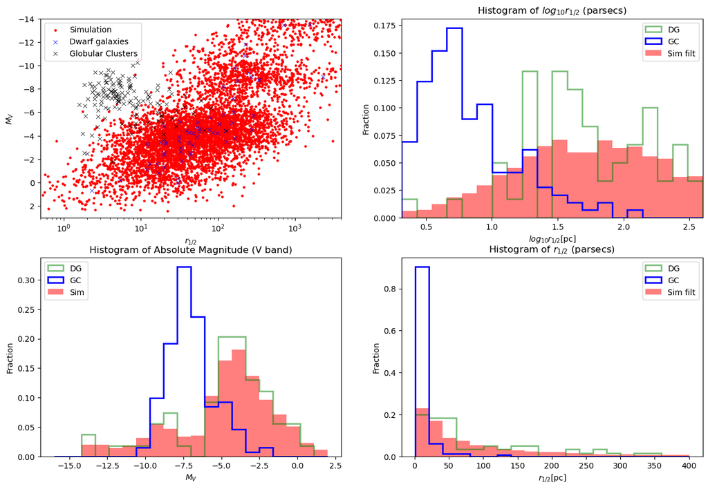

```python
param['Mv_hlr_from_data'] = 'dg'
RA_pix, DEC_pix, r_exp, ell, pa, dist, mM, hp_sample_un, MV = gen_clus_file(param)

Mv_DG, hlr_DG = read_ref_dg(param)
Mv_GC, hlr_GC = read_ref_gc(param)

hlr_pc = np.multiply(1.7, r_exp)

show_plots(Mv_DG, Mv_GC, MV, hlr_DG, hlr_GC, hlr_pc)
```

```python
with open('objects.dat') as f:
    first_line = f.readline()

table = tabulate.tabulate(np.loadtxt('objects.dat')[:][0:20],
                          tablefmt='html',
                          headers=(first_line[1:].split()))

table
```

| HPX | L | B | RA | DEC | r_exp | ell | pa | MV | dist |
| --- | --- | --- | --- | --- | --- | --- | --- | --- | --- |
| 18082 | 99.4542 | -62.0894 | 2.1094 | -1.1937 | 75.96 | 0.16 | 159.15 | -8.06 | 14838.3 |
| 18081 | 102.307 | -62.5593 | 3.5156 | -1.1937 | 4.57 | 0.01 | 145.06 | -4.3 | 44790.1 |
| 18062 | 105.246 | -62.9701 | 4.9219 | -1.1937 | 18.54 | 0.13 | 175.21 | -2.58 | 45156 |
| 18061 | 108.261 | -63.3189 | 6.3281 | -1.1937 | 4.17 | 0.08 | 92.34 | -3.47 | 16061.5 |
| 18066 | 111.343 | -63.6033 | 7.7344 | -1.1937 | 86.6 | 0.18 | 146.65 | -6 | 35631.5 |
| 18065 | 114.48 | -63.8211 | 9.1406 | -1.1937 | 112.41 | 0.06 | 47.17 | -3.09 | 24070.4 |
| 17982 | 117.657 | -63.9707 | 10.5469 | -1.1937 | 1.92 | 0.02 | 71.99 | -5.4 | 89075.3 |
| 17981 | 120.861 | -64.0509 | 11.9531 | -1.1937 | 9.04 | 0.11 | 134.51 | -3.44 | 88186.4 |
| 18018 | 124.075 | -64.0611 | 13.3594 | -1.1937 | 7.12 | 0.09 | 122.55 | -3.18 | 38673 |
| 18017 | 127.283 | -64.0011 | 14.7656 | -1.1937 | 53.83 | 0.03 | 168.98 | -3.42 | 11308.9 |
| 17998 | 130.469 | -63.8714 | 16.1719 | -1.1937 | 10.28 | 0.08 | 124.11 | -2.9 | 96292.8 |
| 17997 | 133.619 | -63.6732 | 17.5781 | -1.1937 | 63.45 | 0.05 | 37.4 | -4.48 | 37771.4 |
| 18002 | 136.718 | -63.4078 | 18.9844 | -1.1937 | 218.02 | 0.03 | 150.67 | -2.98 | 18027.2 |
| 18001 | 139.754 | -63.0774 | 20.3906 | -1.1937 | 60.42 | 0.03 | 116.04 | 1.06 | 93320.1 |
| 17662 | 142.716 | -62.6843 | 21.7969 | -1.1937 | 0.66 | 0.15 | 112.22 | -1.61 | 17255 |
| 17661 | 145.594 | -62.2311 | 23.2031 | -1.1937 | 9.57 | 0.09 | 36.58 | -1.71 | 21203.2 |
| 17826 | 148.383 | -61.7208 | 24.6094 | -1.1937 | 8.53 | 0.02 | 59.28 | -6.13 | 20767.4 |
| 17825 | 151.077 | -61.1565 | 26.0156 | -1.1937 | 8.08 | 0.15 | 50.14 | -4.78 | 70032.8 |
| 17806 | 153.672 | -60.5412 | 27.4219 | -1.1937 | 438.15 | 0.05 | 106.11 | -3.98 | 69665.2 |
| 17805 | 156.168 | -59.8781 | 28.8281 | -1.1937 | 32.08 | 0.02 | 154.84 | -5.72 | 16815.4 |

# Globular clusters

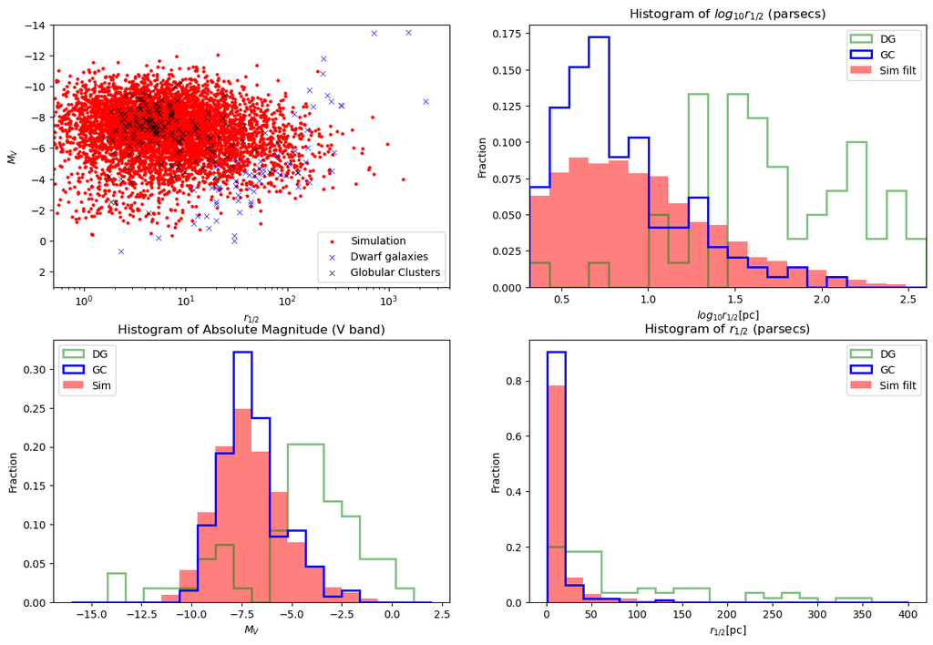

```python
param['Mv_hlr_from_data'] = 'gc'
RA_pix, DEC_pix, r_exp, ell, pa, dist, mM, hp_sample_un, MV = gen_clus_file(param)

Mv_DG, hlr_DG = read_ref_dg(param)
Mv_GC, hlr_GC = read_ref_gc(param)

hlr_pc = np.multiply(1.7, r_exp)

show_plots(Mv_DG, Mv_GC, MV, hlr_DG, hlr_GC, hlr_pc)
```

```python
with open('objects.dat') as f:
    first_line = f.readline()

table = tabulate.tabulate(np.loadtxt('objects.dat')[:][0:20],
                          tablefmt='html',
                          headers=(first_line[1:].split()))

table
```

| HPX | L | B | RA | DEC | r_exp | ell | pa | MV | dist |
| --- | --- | --- | --- | --- | --- | --- | --- | --- | --- |
| 18082 | 99.4542 | -62.0894 | 2.1094 | -1.1937 | 19.13 | 0.08 | 69.8 | -7.17 | 99093.3 |
| 18081 | 102.307 | -62.5593 | 3.5156 | -1.1937 | 45.58 | 0.05 | 118.39 | -4.05 | 11228.2 |
| 18062 | 105.246 | -62.9701 | 4.9219 | -1.1937 | 1.72 | 0.04 | 97.75 | -7.65 | 40226 |
| 18061 | 108.261 | -63.3189 | 6.3281 | -1.1937 | 5.68 | 0.19 | 156.68 | -6.61 | 20468.5 |
| 18066 | 111.343 | -63.6033 | 7.7344 | -1.1937 | 13.23 | 0.09 | 149.49 | -8.04 | 39771 |
| 18065 | 114.48 | -63.8211 | 9.1406 | -1.1937 | 3.28 | 0.11 | 4.6 | -4.43 | 80542 |
| 17982 | 117.657 | -63.9707 | 10.5469 | -1.1937 | 19.89 | 0.01 | 38.66 | -5.34 | 41757.2 |
| 17981 | 120.861 | -64.0509 | 11.9531 | -1.1937 | 6.83 | 0.03 | 155.52 | -6.81 | 19651.6 |
| 18018 | 124.075 | -64.0611 | 13.3594 | -1.1937 | 3.16 | 0.04 | 80.36 | -5.06 | 22502.4 |
| 18017 | 127.283 | -64.0011 | 14.7656 | -1.1937 | 16.25 | 0.04 | 17.2 | -5.26 | 42965.3 |
| 17998 | 130.469 | -63.8714 | 16.1719 | -1.1937 | 4.98 | 0 | 170.48 | -10.09 | 75156.6 |
| 17997 | 133.619 | -63.6732 | 17.5781 | -1.1937 | 11.41 | 0.15 | 31 | -8.82 | 18981.6 |
| 18002 | 136.718 | -63.4078 | 18.9844 | -1.1937 | 3.21 | 0.18 | 130.14 | -7.07 | 90761.5 |
| 18001 | 139.754 | -63.0774 | 20.3906 | -1.1937 | 0.64 | 0.08 | 77.02 | -7.89 | 18999.2 |
| 17662 | 142.716 | -62.6843 | 21.7969 | -1.1937 | 1.1 | 0.05 | 44.54 | -7.68 | 10874.8 |
| 17661 | 145.594 | -62.2311 | 23.2031 | -1.1937 | 9.31 | 0.18 | 14.99 | -9.89 | 30573.5 |
| 17826 | 148.383 | -61.7208 | 24.6094 | -1.1937 | 8.86 | 0.05 | 142.48 | -5.02 | 55319.5 |
| 17825 | 151.077 | -61.1565 | 26.0156 | -1.1937 | 1.06 | 0.12 | 123.98 | -8.42 | 69359.3 |
| 17806 | 153.672 | -60.5412 | 27.4219 | -1.1937 | 2.82 | 0.18 | 157.45 | -8.27 | 58536.7 |
| 17805 | 156.168 | -59.8781 | 28.8281 | -1.1937 | 4.47 | 0.09 | 55.33 | -8.62 | 12512 |

# Simulation with flat likelihood in Mv x r1/2 space

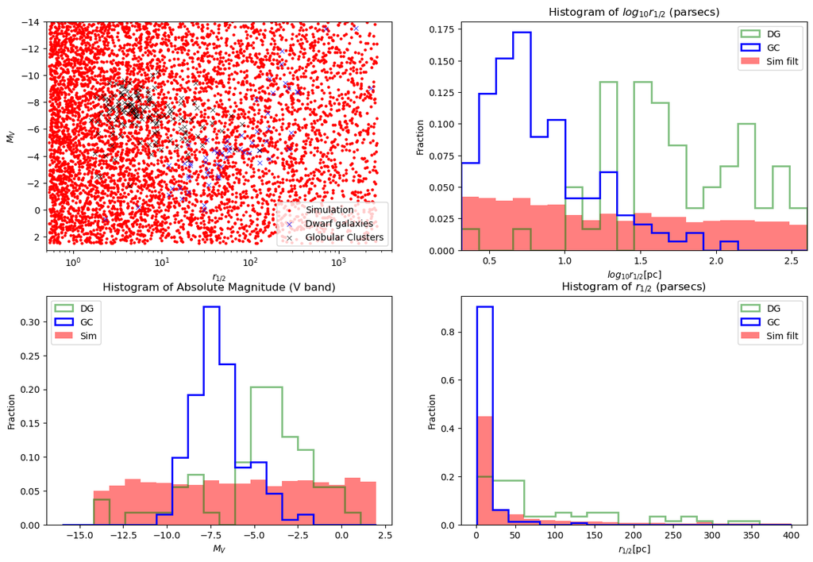

```python
param['Mv_hlr_from_data'] = 'False'
RA_pix, DEC_pix, r_exp, ell, pa, dist, mM, hp_sample_un, MV = gen_clus_file(param)

Mv_DG, hlr_DG = read_ref_dg(param)
Mv_GC, hlr_GC = read_ref_gc(param)

hlr_pc = np.multiply(1.7, r_exp)

show_plots(Mv_DG, Mv_GC, MV, hlr_DG, hlr_GC, hlr_pc)
```

```python
with open('objects.dat') as f:
    first_line = f.readline()

table = tabulate.tabulate(np.loadtxt('objects.dat')[:][0:20],
                          tablefmt='html',
                          headers=(first_line[1:].split()))

table
```

| HPX | L | B | RA | DEC | r_exp | ell | pa | MV | dist |
| --- | --- | --- | --- | --- | --- | --- | --- | --- | --- |
| 18082 | 99.4542 | -62.0894 | 2.1094 | -1.1937 | 36.57 | 0.12 | 134.09 | 1.28 | 64616.3 |
| 18081 | 102.307 | -62.5593 | 3.5156 | -1.1937 | 11.85 | 0.19 | 117.85 | -11.85 | 96775 |
| 18062 | 105.246 | -62.9701 | 4.9219 | -1.1937 | 1.44 | 0.07 | 173.83 | -12.41 | 10031.5 |
| 18061 | 108.261 | -63.3189 | 6.3281 | -1.1937 | 0.4 | 0.08 | 122.52 | -8.61 | 15721.5 |
| 18066 | 111.343 | -63.6033 | 7.7344 | -1.1937 | 0.66 | 0 | 118.5 | 0.26 | 20332.4 |
| 18065 | 114.48 | -63.8211 | 9.1406 | -1.1937 | 437.35 | 0.16 | 50.15 | -6.99 | 71100.8 |
| 17982 | 117.657 | -63.9707 | 10.5469 | -1.1937 | 451.04 | 0.08 | 103.97 | -11.77 | 36747.5 |
| 17981 | 120.861 | -64.0509 | 11.9531 | -1.1937 | 0.91 | 0.03 | 8.8 | -3.15 | 22538.5 |
| 18018 | 124.075 | -64.0611 | 13.3594 | -1.1937 | 0.51 | 0.19 | 69.1 | -0.87 | 25016.8 |
| 18017 | 127.283 | -64.0011 | 14.7656 | -1.1937 | 1.33 | 0.09 | 178.37 | -12.78 | 81024 |
| 17998 | 130.469 | -63.8714 | 16.1719 | -1.1937 | 50.88 | 0.08 | 86.77 | -5.84 | 17386 |
| 17997 | 133.619 | -63.6732 | 17.5781 | -1.1937 | 683.12 | 0.15 | 69.66 | -8 | 14504 |
| 18002 | 136.718 | -63.4078 | 18.9844 | -1.1937 | 0.37 | 0.19 | 123.8 | 0.33 | 91833.9 |
| 18001 | 139.754 | -63.0774 | 20.3906 | -1.1937 | 1.22 | 0.11 | 50.78 | 1.25 | 73440 |
| 17662 | 142.716 | -62.6843 | 21.7969 | -1.1937 | 0.85 | 0.08 | 37.82 | -7.11 | 25106.6 |
| 17661 | 145.594 | -62.2311 | 23.2031 | -1.1937 | 2.09 | 0.13 | 46.14 | -9.43 | 10887.5 |
| 17826 | 148.383 | -61.7208 | 24.6094 | -1.1937 | 0.55 | 0.06 | 146.11 | -7.77 | 13010.3 |
| 17825 | 151.077 | -61.1565 | 26.0156 | -1.1937 | 1.35 | 0.12 | 133.9 | -11.99 | 15167.4 |
| 17806 | 153.672 | -60.5412 | 27.4219 | -1.1937 | 3.59 | 0.18 | 17.7 | -9.63 | 70416.8 |
| 17805 | 156.168 | -59.8781 | 28.8281 | -1.1937 | 0.64 | 0.09 | 112.02 | -12.04 | 99678.8 |